# Bootstrapping

## Bootstrapping / Bootstrap

We are going to learn a general method that aims to address:

- How much uncertainty is associated with an estimate.
- Specifically, how to calculate the standard error of a (potentially complicated) statistic.

This can then be used to answer questions such as:

- Is the new treatment genuinely more effective than the standard one, or could the difference be due to chance?
- Is this month’s drop in car rentals a real trend or just random fluctuation?
- What is a 95% confidence interval for the true vaccination rate in the population?

# Recap: sampling distributions

## Recall: population and sample

From the sampling lecture: we want the average length $\mu$ of red-tailed hawks in the Santa Barbara area.

- **Target population:** all the hawks. We simulated 500 of them, so in simulation we know the we know true $\mu$.
- **Sample:** the 50 hawks we imagine capturing and measuring, chosen by SRS.
- **Estimate:** the sample mean $\hat\mu$, computed from the sample.

## Recall: population and sample

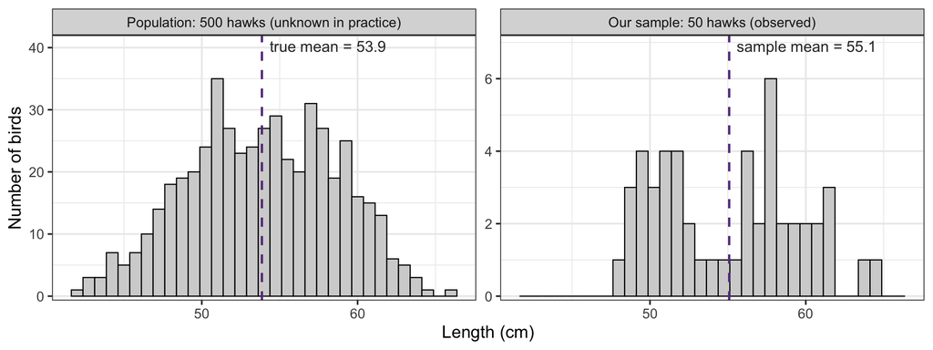

In practice we only ever see the right panel. The left panel, and $\mu$, are unknown. That is why we sample.

## Recall: the sampling distribution

The sample mean $\hat\mu$ is a **random variable**. Its randomness comes from *which* hawks happen to be selected: a different sample of 50 would give a different $\hat\mu$.

Its probability distribution is called the **sampling distribution**.

The sampling distribution is **counterfactual**. We imagine many possible worlds, each running the same study but drawing different hawks from the same population. In reality, we can only run the study once.

A common misconception: the sampling distribution of $\hat\mu$ is **not** the distribution of individual hawk lengths. Averages vary much less than individuals do.

## Recall: simulating the sampling distribution

Because we invented the population, we can draw as many samples from it as we like. This is the simulation from the sampling lecture:

```r
set.seed(123)
sample_size <- 50
num_reps <- 5e4
sample_means <- numeric(num_reps)

for (i in 1:num_reps) {
  sample_indices <- sample(1:nrow(hawk_pop), sample_size, replace = FALSE)
  sample_means[i] <- mean(hawk_pop[sample_indices, ]$length)
}
```

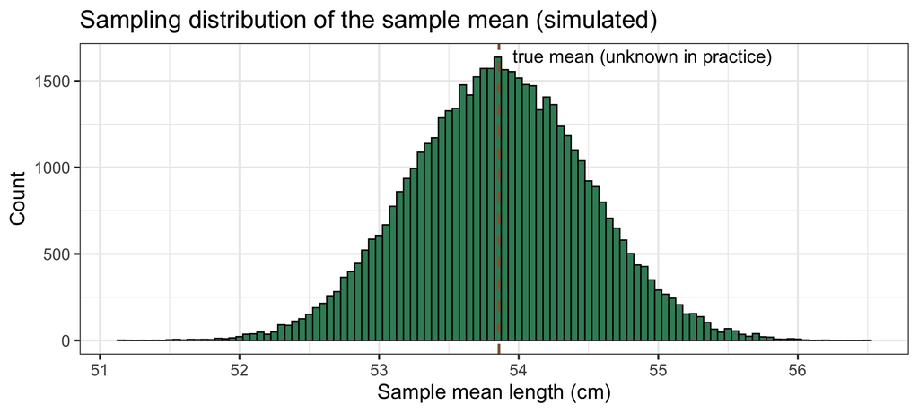

```r
sd(hawk_pop$length) # spread of individual hawk lengths
```

```
[1] 4.737549
```

```r
sd(sample_means)    # spread of the sampling distribution of the sample mean
```

```
[1] 0.634777
```

${\rm SD}(\hat\mu)$ is called the **standard error** of $\hat(\mu)$: roughly how far a typical estimate lands from $\mu$.

## In reality we only have the sample

Simulation only worked because we imagined having access to the whole population.

|  | Simulation (sampling lecture) | A real study |
| --- | --- | --- |
| Population | known | **unavailable** |
| Number of samples | as many as we like | **one** |
| Sampling distribution | a histogram we can generate | **never seen** |

If we knew the population, we wouldn’t need to sample in the first place. And we can’t go back to the field and catch 50,000 more sets of 50 hawks.

So how do we estimate the standard error from our **one** sample?

## Quantifying uncertainty

**Estimating standard errors is one of the foundational goals of statistics.**

How do statisticians estimate standard errors from a single sample?

- **Math:** derive a formula for the standard error
- **Computational:** use algorithms to try to approximate the standard error
- **Bayesian Frameworks**: PSTAT 115

## Math for ``simple’’ estimators

Let’s begin with sample mean $\hat \mu$ estimating the population mean $\mu$.

We know $\hat \mu$ is an unbiased estimator of $\mu$ given IID samples (sample size $n$):

$$E[\hat \mu] = n^{-1}\sum_{i=1}^n E[Y_i] = E[Y_1] = \mu$$

We also know its theoretical variance for IID samples:

$$Var[\hat \mu] = n^{-2}Var(\sum_{i=1}^n Y_i) = n^{-2}\sum_{i=1}^n Var[Y_i] = n^{-1}Var[Y_1]$$

## Math for ``simple’’ estimators

We *estimate* the variance of $Y_1$ by

$$\widehat{Var}[Y_1] = \frac{1}{n-1} \sum_{i=1}^n\left(Y_i-\hat\mu\right)^2 \text{ or }\frac{1}{n} \sum_{i=1}^n\left(Y_i-\hat\mu\right)^2.$$

So our estimate of $Var[\hat \mu]$ is

$$\widehat{Var}[\hat \mu] = n^{-1}\widehat{Var}[Y_1] = \frac{1}{n(n-1)} \sum_{i=1}^n\left(Y_i-\hat{\mu}\right)^2$$

## Sometimes the math is too hard

- What about the variance of sample median?
- Sample correlation coefficient?
- Variance of sample variance?
- The inverse probability weighted (IPW) estimate of hawk length from the sampling lecture?

Are there options without figuring out the math?

# Bootstrap the sample mean

## The bootstrap

In 1979, Bradley Efron proposed a procedure to estimate the distribution/variability of a **statistic** (a number calculated from our sample).

If we had access to the whole population we could just simulate the sampling distribution

The “trick”: let’s pretend the true population distribution is well approximated by our sample?

## The bootstrap

The name bootstrap originates from the phrase “pull oneself up by one’s bootstraps.” The phrase refers to situations where someone attempts a very challenging task without relying on external assistance.

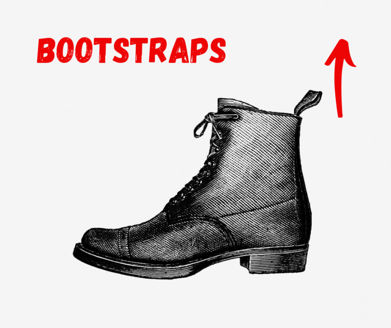

Bootstrapping does not rely on extra information (formulas, models, etc.) and makes relatively weak modeling assumptions (somewhat in the spirit of the CLT).

The word *booting* in computer science shares the same origin. How can a computer restart (reboot) itself?

## Bootstrapping

Suppose we have an IID data sample $(Y_1,\ldots,Y_n)$ of size $n$ from a population.

For example, the $Y_i$ form a SRS (with replacement) from the same population.

```r
set.seed(1)
sample_size <- 50
true_var <- true_mean <- 3
my_sample <- rpois(sample_size, lambda = true_mean) # sample 50 data points from the population
my_sample |> head()
```

```
[1] 2 2 3 5 2 5
```

```r
sample_mean <- my_sample |> mean()
sample_mean
```

```
[1] 3.12
```

Bootstrapping treats the sample as a proxy for the target population. It asks us to **resample with replacement** from our sample.

## Create one bootstrap sample

Create a *bootstrap sample* of size $n$ by SRS **with** replacement from the (real) sample. This can be easily done using `sample()`

```r
boot_sample <- sample(my_sample,
                      size = sample_size,
                      replace = TRUE) #create one bootstrap sample from the data
one_boot_mean <- boot_sample |> mean()
one_boot_mean
```

```
[1] 3.26
```

There are two important details:

- `boot_sample` needs to have the sample size as the original data.
- we have to SRS with replacement (why?)

## The complete bootstrap procedure

Repeat many times:

1. Resample with replacement a “new sample” of the same size from my original sample
2. Compute more estimate on the “new sample”, e.g. compute sample mean. This a ``bootstrap sample’’ of my estimate.

The distribution of your many bootstrap samples will reflect the true sampling variability.

## The complete bootstrap procedure

Repeat SRS **with** replacement from the data many times:

```r
n_bootstrap <- 2e3
bootstrap_means <- numeric(n_bootstrap)

for (rep_id in 1:n_bootstrap) {
  boot_sample <- sample(my_sample,
                        size = length(my_sample),
                        replace = TRUE)
  bootstrap_means[rep_id] <- mean(boot_sample)
}

bootstrap_means |> head()
```

```
[1] 3.14 2.94 3.16 3.14 3.04 3.20
```

This is very similar to a simulation study, except that in simulation we resample from a **hypothetical population**, while in the bootstrap we resample from the observed **sample**.

In other words, a simulation study is for methodological investigation of estimators and study plans, whereas `bootstrap_means` is a *statistic* computed from data.

## Use Bootstrap to quantify variability

Bootstrap uses the variance of `bootstrap_means` as an **estimate** of the variance of sample mean.

```r
n_bootstrap <- 2e3
bootstrap_means <- numeric(n_bootstrap)

for (rep_id in 1:n_bootstrap) {
  boot_sample <- sample(my_sample,
                        size = length(my_sample),
                        replace = TRUE)
  bootstrap_means[rep_id] <- mean(boot_sample)
}
```

```r
bootstrap_means |> head()
```

```
[1] 3.14 2.94 3.16 3.14 3.04 3.20
```

```r
boot_var <- var(bootstrap_means)
boot_var
```

```
[1] 0.04913396
```

The method of bootstrapping uses `boot_var` as an estimator of ${\rm Var}(\hat \mu)$. Mathematically, `boot_var` is $\widehat{\rm Var}(\hat \mu)$.

## Use Bootstrap to quantify variability

When we report a sample mean, we usually append an estimate of its variability (i.e., the standard error):

$$\hat\mu {\rm\ with\ } \widehat{\operatorname{SE}}(\hat \mu) = \hat\mu {\rm\ with\ } \widehat{\operatorname{SD}}(\hat \mu).$$

```r
sample_mean
```

```
[1] 3.12
```

```r
boot_se <- sqrt(boot_var)
boot_se
```

```
[1] 0.2216618
```

```r
# boot_se <- sd(bootstrap_means)
# boot_se
```

Sample mean $\hat \mu$ is a random variable, so it has a non-zero standard deviation

$${\rm SD}(\hat \mu) = \sqrt{{\rm Var}(\hat \mu)}$$
Very often, people use the word **standard error** equivalently as ${\rm SD}(\hat \mu)$:

$${\rm SE}(\hat \mu) = {\rm SD}(\hat \mu) = \sqrt{{\rm Var}(\hat \mu)}$$
It typically decreases as the sample size grows. For example, “the standard error of the sample mean” is the same as “the standard deviation of the sample mean” = $\sqrt{n^{-1}Var[Y]}$.

*Language warning:* However, people also use the word **standard error** for the estimated standard error:

$$\widehat{\rm SE}(\hat \mu) = \widehat{\rm SD}(\hat \mu) = \sqrt{\widehat{\rm Var}(\hat \mu)}$$

## Formula-based standard error

As we stated in the beginning, we can also use an explicit formula to estimate the standard error of $\hat\mu$

$$\widehat{Var}[\hat \mu] = n^{-1}\widehat{Var}[Y_1] = \frac{1}{n(n-1)} \sum_{i=1}^n\left(Y_i-\hat{\mu}\right)^2$$

```r
sample_mean
```

```
[1] 3.12
```

```r
formula_var <- sample_size^(-1) * var(my_sample) #the original data
formula_var
```

```
[1] 0.05113469
```

```r
formula_se <- sqrt(formula_var)
formula_se
```

```
[1] 0.2261298
```

Compare them with the Bootstrap standard error

```r
boot_var
```

```
[1] 0.04913396
```

```r
boot_se
```

```
[1] 0.2216618
```

Guess what, we simulated the data. So we know

$$Var[\hat\mu] = n^{-1}Var[Y_1] = n^{-1} \lambda$$
where $\lambda$ is both the mean and variance of a Poisson distribution.

```r
oracle_var <- sample_size^(-1) * true_var #THIS IS NOT A STATISTIC
oracle_var
```

```
[1] 0.06
```

```r
oracle_se <- sqrt(oracle_var)
oracle_se
```

```
[1] 0.244949
```

What are we computing below? Is `formula_se` or `boot_se` performing slightly better?

```r
formula_se/oracle_se
```

```
[1] 0.9231711
```

```r
boot_se/oracle_se
```

```
[1] 0.9049306
```

Report the sample mean together with its standard error from bootstrap.

## Let’s try a larger sample size, but everything else stays the same

```r
set.seed(4)
sample_size <- 500
true_var <- true_mean <- 3
my_sample <- rpois(sample_size, lambda = true_mean) # sample 500 data points from the population
sample_mean <- my_sample |> mean()
sample_mean
```

```
[1] 3.014
```

```r
n_bootstrap <- 2e3
bootstrap_means <- numeric(n_bootstrap)

for (rep_id in 1:n_bootstrap) {
  boot_sample <- sample(my_sample,
                        size = length(my_sample),
                        replace = TRUE)
  bootstrap_means[rep_id] <- mean(boot_sample)
}

boot_se <- sd(bootstrap_means)
boot_se
```

```
[1] 0.07862161
```

Compare the sample mean with that of sample size = 50. What about its standard error?

```r
oracle_var <- sample_size^(-1) * true_var
oracle_var
```

```
[1] 0.006
```

```r
oracle_se <- sqrt(oracle_var)
boot_se / oracle_se
```

```
[1] 1.015001
```

## Bootstrap with median

The standard error of sample mean can be assessed using either bootstrapping or explicit formula. For more complicated statistics the formula may not be available.

Sample median, although easy to compute, is mathematically more complicated. Its SE formula is not as transparent.

But we can apply bootstrapping to evaluate the variability of the sample median for data from a $\chi^2$ distribution (which is not the easiest population to work with analytically).

```r
set.seed(8)
sample_size <- 200
chisq_df <- 2
my_sample <- rchisq(sample_size,
                    df = chisq_df)
sample_median <- my_sample |> median()
sample_median
```

```
[1] 1.571045
```

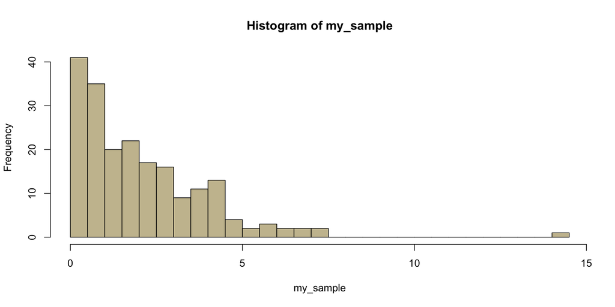

```r
hist(my_sample, col = "#C9BF9D", breaks = 30)
```

```r
true_median <- qchisq(1/2, df = chisq_df)
true_median #\mu
```

```
[1] 1.386294
```

## Bootstrap resampling

Similar to the sample mean case, we use resampling with replacement from our observed data to obtain a standard error.

How should I modify this?

```r
n_bootstrap <- 2e3
bootstrap_means <- numeric(n_bootstrap)

for (rep_id in 1:n_bootstrap) {
  boot_sample <- sample(my_sample,
                        size = length(my_sample),
                        replace = TRUE)
  bootstrap_means[rep_id] <- mean(boot_sample)
}
```

```r
n_bootstrap <- 2e3
bootstrap_medians <- numeric(n_bootstrap)

for (rep_id in 1:n_bootstrap) {
  boot_sample <- sample(my_sample,
                        size = length(my_sample),
                        replace = TRUE)
  bootstrap_medians[rep_id] <- median(boot_sample) #median() instead of mean()
}

boot_se <- sd(bootstrap_medians)
boot_se # \hat{SD(\hat \mu)}
```

```
[1] 0.1517892
```

```r
sample_median # \hat \mu
```

```
[1] 1.571045
```

## Simulated distribution of sample median

How much should we trust the standard error from bootstrap?

We can use simulation to approximate the theoretical standard error $SE[\hat \mu_{median}]$.

If our estimation $\widehat{SE}[\hat \mu_{median}]$ is close to it, we will believe bootstrap is applicable to sample median and probably be more confident when implementing it in practice.

```r
n_simulation <- 5e3
simulation_medians <- numeric(n_simulation)

for (rep_id in 1:n_simulation) {
  simu_sample <- rchisq(sample_size,
                        df = chisq_df)

  simulation_medians[rep_id] <- median(simu_sample)
}

theoretical_se <- sd(simulation_medians)
theoretical_se
```

```
[1] 0.1418133
```

What is `theoretical_se` in our mathematical notation?

Let’s compare the sample version quantities and the population version.

$\mu, \hat\mu, {\rm SD}(\hat \mu), \widehat{\rm SD}(\hat \mu)$

## Constructing a bootstrap confidence interval

Once we have the bootstrap distribution of medians, we can also use its quantiles to form a confidence interval for the population median.

```r
type_1_error <- 0.05
lower_bound <- quantile(bootstrap_medians,
                        probs = type_1_error/2)
higher_bound <- quantile(bootstrap_medians,
                         probs = 1 - type_1_error/2)
```

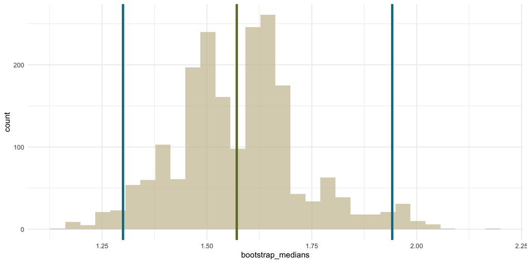

The blue lines mark the lower and upper bounds (2.5% and 97.5%), and the green line marks our sample median.

```r
print(paste0("[",
             formatC(lower_bound, format = "f", digits = 3), ", ",
             formatC(higher_bound, format = "f", digits = 3), "]"))
```

```
[1] "[1.300, 1.942]"
```

```r
true_median
```

```
[1] 1.386294
```

We can now also see whether the true median falls inside our bootstrap interval.

## Confidence Intervals

- A **confidence interval** is gives a range of plausible values for a population quantity, computed from our sample.
- A **95% confidence interval** comes from a *procedure* that captures the true value in about 95% of samples.
- The true population quantity is a fixed (unknown) number. The interval is what’s random: a different sample would give a different interval.
- Our interval, [1.3, 1.94], either contains the true median or it doesn’t. In practice, we never get to know which.
- “95%” describes the **method’s track record**. The `0.05` in our code (often called $\alpha$) is the fraction of time we expect that our procedure will fail (not cover the true value), and the confidence level is $1 - \alpha$ = 95%.

## What does “95% confidence” mean?

Like the sampling distribution, it’s a counterfactual: imagine repeating the **entire study** many times.

Our $\chi^2$ population is simulated, so here we actually can. Each repetition draws a new sample, bootstraps it, and builds a 95% interval:

```r
set.seed(2026)
n_studies <- 500
n_boot_ci <- 1e3
ci_lower <- numeric(n_studies)
ci_upper <- numeric(n_studies)
study_median <- numeric(n_studies)

for (study_id in 1:n_studies) {
  new_sample <- rchisq(sample_size, df = chisq_df) # a brand new study
  # replicate() repeats the bootstrap step n_boot_ci times
  boot_medians <- replicate(n_boot_ci,
                            median(sample(new_sample, replace = TRUE)))
  study_median[study_id] <- median(new_sample)
  ci_lower[study_id] <- quantile(boot_medians, probs = 0.025)
  ci_upper[study_id] <- quantile(boot_medians, probs = 0.975)
}
```

What fraction of the intervals contain the true median?

```r
covers <- ci_lower <= true_median & true_median <= ci_upper
mean(covers)
```

```
[1] 0.952
```

## 100 studies, 100 intervals

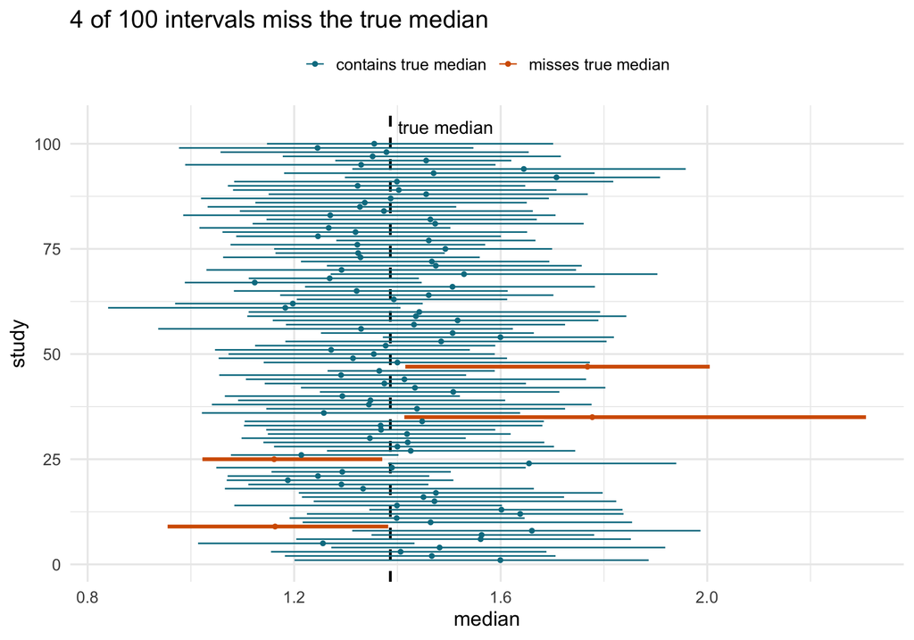

## Incorrect interpretations

**Incorrect:** “There is a 95% probability that the true median is between 1.3 and 1.94.”

Once computed, our interval is fixed, and so is the true median. Either it’s inside or it isn’t; we just don’t know which. (Bayesian statistics, PSTAT 115, *does* make probability statements like this, using a different framework.)

**Incorrect:** “95% of the data fall inside the interval.”

The interval is about the population **median**, not about individual values:

```r
mean(my_sample >= lower_bound & my_sample <= higher_bound) # fraction of our data inside the CI
```

```
[1] 0.135
```

**Correct:** “If we repeated the study many times, about 95% of the intervals built this way would contain the true median.”

**Correct (informal):** “We are 95% confident that the population median is between 1.3 and 1.94.” Here “confident” refers to the method’s track record.

## Confidence level vs. width

All of these come from the **same** bootstrap distribution of medians. Only the quantiles change:

```r
conf_levels <- c(0.50, 0.80, 0.90, 0.95, 0.99)

tibble(confidence = conf_levels,
       lower = quantile(bootstrap_medians, probs = (1 - conf_levels) / 2),
       upper = quantile(bootstrap_medians, probs = 1 - (1 - conf_levels) / 2)) |>
  mutate(width = upper - lower,
         contains_truth = lower <= true_median & true_median <= upper)
```

```
# A tibble: 5 × 5
  confidence lower upper width contains_truth
       <dbl> <dbl> <dbl> <dbl> <lgl>
1       0.5   1.46  1.65 0.189 FALSE
2       0.8   1.38  1.78 0.391 TRUE
3       0.9   1.34  1.85 0.511 TRUE
4       0.95  1.30  1.94 0.642 TRUE
5       0.99  1.21  2.01 0.796 TRUE
```

- Higher confidence means a wider interval. A 100% interval for this median would be $[0, \infty)$: always right, never useful.
- Lower confidence means a narrower interval that misses more often. Our 50% interval misses the true median.
- To get a narrow interval *and* high confidence, collect more data: the standard error shrinks as $n$ grows.

95% is a convention, not a law of nature.

## Break: using resampling to estimate e

Suppose you collected $n$ data points, and you are creating a bootstrap sample by SRS with replacement.

What is the probability that the first data point is not selected into the bootstrap sample?

There are $n$ draws. The probability that data point 1 is not drawn is

$$(1-1/n)^n.$$
And we know that

$$\lim_{n\rightarrow \infty} (1-1/n)^n = e^{-1}.$$

So, for large $n$, the probability of being absent is about $e^{-1}$, and therefore $e \approx 1/\Pr(\text{data point 1 is absent from the bootstrap sample}).$

```r
set.seed(2)
sample_size <- 2e3
sample_index <- 1:sample_size

boot_num <- 1e4
absent_1 <- numeric(boot_num)

for (repeat_index in 1:boot_num) {
  boot_idx <- sample(sample_index,
                     sample_size,
                     replace = TRUE)
  absent_1[repeat_index] <- !(1 %in% boot_idx)
}

p_hat <- mean(absent_1) #probability of data 1 not in the bootstrap sample
e_hat <- 1 / p_hat

tibble(
  true_e = exp(1),
  estimated_e = e_hat,
  error = abs(true_e - estimated_e)
) |> glimpse()
```

```
Rows: 1
Columns: 3
$ true_e      <dbl> 2.718282
$ estimated_e <dbl> 2.73523
$ error       <dbl> 0.01694793
```

# Case study: hawks revisited

## Recall: a biased sample of hawks

In the sampling lecture we simulated a population of 500 red-tailed hawks: 250 females (about 57.5 cm long on average) and 250 males (about 50.5 cm).

Lengths came from dead specimens, and females were **9 times as likely** to be sampled as males.

- The **sample mean** was biased upward: too many long females.
- **Inverse probability weighting (IPW)** removed the bias by giving each hawk the weight $w_i = 1/p_i$:

$$\hat \mu_{IPW} = \frac{\sum_i w_i Y_i}{\sum_i w_i}$$

We also saw that IPW has a **larger variance** than the sample mean. But we learned that by drawing 1000 new samples from the full population, which we can’t do in practice.

**Question:** with only *one* sample of 50 hawks, what is the standard error of $\hat \mu_{IPW}$?

There is no simple formula like ${\rm Var}(\hat\mu) = n^{-1}{\rm Var}(Y_1)$, because the weights make the math messy. Let’s bootstrap it.

## Our one biased sample

We use the same `hawk_pop` from the recap, and draw the same biased sample of 50 hawks as in the sampling lecture (same seed).

```r
hawk_pop_wt <- hawk_pop |>
  mutate(samp_weight = if_else(sex == "female", 9, 1))

set.seed(8888)
biased_n <- 50
samp <- hawk_pop_wt |> slice_sample(n = biased_n, weight_by = samp_weight)
samp |> count(sex)
```

```
# A tibble: 2 × 2
  sex        n
  <chr>  <int>
1 female    44
2 male       6
```

We wrap the IPW estimate in a function so we can reuse it:

```r
ipw_mean <- function(lengths, samp_weights) {
  w <- 1 / samp_weights
  sum(w * lengths) / sum(w)
}

naive_est <- mean(samp$length)
ipw_est <- ipw_mean(samp$length, samp$samp_weight)
c(sample_mean = naive_est, ipw = ipw_est)
```

```
sample_mean         ipw
   56.32341    53.77296
```

## One bootstrap sample of hawks

Resample **hawks** (whole rows of `samp`) with replacement, not just their lengths. Each resampled hawk brings its sex and its sampling weight along.

```r
set.seed(100)
boot_hawks <- samp |> slice_sample(n = nrow(samp), replace = TRUE)
boot_hawks |> count(sex)
```

```
# A tibble: 2 × 2
  sex        n
  <chr>  <int>
1 female    45
2 male       5
```

```r
ipw_mean(boot_hawks$length, boot_hawks$samp_weight)
```

```
[1] 52.79379
```

The number of males changes from one bootstrap sample to the next, just as it would across real samples.

Notice there is no `weight_by = samp_weight` in the resampling step. Why not?

Our sample came from the biased design, so it already over-represents females. Resampling it uniformly mimics drawing new samples under that same design. Adding `weight_by` would favor females a second time.

The weights belong only inside the statistic, `ipw_mean()`.

## The complete bootstrap

Repeat 2000 times, computing both estimators on every bootstrap sample:

```r
n_bootstrap <- 2e3
boot_naive <- numeric(n_bootstrap)
boot_ipw <- numeric(n_bootstrap)

for (rep_id in 1:n_bootstrap) {
  boot_hawks <- samp |> slice_sample(n = nrow(samp), replace = TRUE)
  boot_naive[rep_id] <- mean(boot_hawks$length)
  boot_ipw[rep_id] <- ipw_mean(boot_hawks$length, boot_hawks$samp_weight)
}

sd(boot_naive) # bootstrap SE of the sample mean
```

```
[1] 0.5053262
```

```r
sd(boot_ipw)   # bootstrap SE of the IPW estimate
```

```
[1] 1.074306
```

We report: IPW estimate 53.77 cm, with bootstrap standard error 1.07 cm.

From one sample, the bootstrap reaches the conclusion that needed the whole population in the sampling lecture: the IPW estimate is about twice as variable as the sample mean.

## Did the bootstrap get it right?

We simulated the population, so we can check. Here is the simulation from the sampling lecture: draw 1000 new biased samples from the **whole population** (impossible in practice).

```r
set.seed(40221)
n_simulation <- 1e3
simulation_naive <- numeric(n_simulation)
simulation_ipw <- numeric(n_simulation)

for (rep_id in 1:n_simulation) {
  simu_hawks <- hawk_pop_wt |>
    slice_sample(n = biased_n, weight_by = samp_weight)
  simulation_naive[rep_id] <- mean(simu_hawks$length)
  simulation_ipw[rep_id] <- ipw_mean(simu_hawks$length, simu_hawks$samp_weight)
}
```

```r
tibble(estimator = c("sample mean", "IPW"),
       simulated_se = c(sd(simulation_naive), sd(simulation_ipw)), # needs the population
       bootstrap_se = c(sd(boot_naive), sd(boot_ipw)))             # needs only our sample
```

```
# A tibble: 2 × 3
  estimator   simulated_se bootstrap_se
  <chr>              <dbl>        <dbl>
1 sample mean        0.501        0.505
2 IPW                1.13         1.07
```

The bootstrap standard errors are close to the simulated ones for both estimators.

## The bootstrap sees variability, not bias

We compare centered distributions: bootstrap estimates minus our estimate, versus simulated estimates minus the true mean.

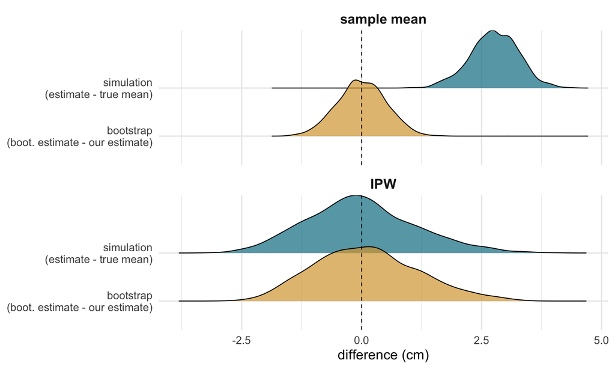

- **IPW:** the two distributions line up. The bootstrap captures the spread.
- **Sample mean:** the spreads match, but the simulated distribution sits about 2.5 cm to the right. That shift is the bias, and the bootstrap cannot see it.

Why? The bootstrap treats our sample as if it were the population. Every bootstrap sample has the same female-heavy mix, so the bootstrap sample means scatter around *our* sample mean, not around the true mean.

## Bootstrap confidence intervals

Percentile intervals, as we did for the median:

```r
ci_naive <- quantile(boot_naive, probs = c(0.025, 0.975))
ci_ipw <- quantile(boot_ipw, probs = c(0.025, 0.975))
ci_naive
```

```
    2.5%    97.5%
55.34218 57.28769
```

```r
ci_ipw
```

```
    2.5%    97.5%
51.97856 56.12780
```

```r
population_mean # known only because we simulated the population
```

```
[1] 53.85889
```

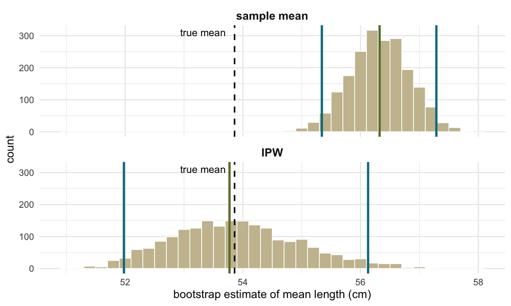

Blue lines: 2.5% and 97.5% bounds. Green line: our estimate. Dashed line: true mean.

The sample-mean interval is narrow and *confidently wrong*: it misses the true mean entirely. The IPW interval is wider, but it covers the truth.

## A common mistake: resampling only the lengths

What goes wrong in this version?

```r
set.seed(100)
boot_ipw_wrong <- numeric(n_bootstrap)

for (rep_id in 1:n_bootstrap) {
  boot_lengths <- sample(samp$length, replace = TRUE)
  boot_ipw_wrong[rep_id] <- ipw_mean(boot_lengths, samp$samp_weight) # weights stay put!
}
```

```r
c(center = mean(boot_ipw_wrong), se = sd(boot_ipw_wrong))
```

```
    center         se
56.3273305  0.8810556
```

```r
c(ipw_est = ipw_est, naive_est = naive_est, correct_boot_se = sd(boot_ipw))
```

```
        ipw_est       naive_est correct_boot_se
      53.772956       56.323408        1.074306
```

The lengths get separated from their hawks, so a long female length can land in a male’s slot and receive a male’s large weight. The weights no longer correct anything. The bootstrap distribution centers on the biased sample mean instead of our IPW estimate, and its standard error is off too.

**Rule:** resample whole units (rows), so every variable that belongs to a hawk stays with that hawk.

## Takeaways: bootstrapping the IPW estimate

- The bootstrap gave a standard error for $\hat\mu_{IPW}$ with **no formula**. We just recomputed the statistic on each bootstrap sample.
- **Resample whole hawks, uniformly.** The sample already reflects the biased design. The weights are used only to compute the statistic.
- The bootstrap measures **variance, not bias**. It cannot fix a biased estimator. Fix the bias with the estimator (here, IPW), then use the bootstrap to measure what that correction costs in variance.